# Black Friday Dataset from AV

KISHORE

January 28, 2017

### Data explored here istaken from Analytics Vidya practice problem.

### The code to create new features is taken from another member (vopani)

loading libraries

```r
library(dummies)
library(plyr)
```

```r
library(ggplot2)
train <- read.csv("C:/Users/Admin/Downloads/Black Friday/train_oSwQCTC/train.csv", stringsAsFactors=F)
```

onehot-encoding city variable

```r
X_train <- train
X_train <- dummy.data.frame(X_train, names=c("City_Category"), sep="_")
```

Converting age variable to numeric

```r
X_train$Age[X_train$Age == "0-17"] <- "15"
X_train$Age[X_train$Age == "18-25"] <- "21"
X_train$Age[X_train$Age == "26-35"] <- "30"
X_train$Age[X_train$Age == "36-45"] <- "40"
X_train$Age[X_train$Age == "46-50"] <- "48"
X_train$Age[X_train$Age == "51-55"] <- "53"
X_train$Age[X_train$Age == "55+"] <- "60"
X_train$Age <- as.integer(X_train$Age)
```

Converting stay in current city to numeric

```r
X_train$Stay_In_Current_City_Years[X_train$Stay_In_Current_City_Years == "4+"] <- "4"
X_train$Stay_In_Current_City_Years <- as.integer(X_train$Stay_In_Current_City_Years)
```

converting Gender to binary

```r
X_train$Gender <- ifelse(X_train$Gender == "F", 1, 0)
```

Feature representing the count of each user

```r
user_count <- ddply(X_train, .(User_ID), nrow)
names(user_count)[2] <- "User_Count"
X_train <- merge(X_train, user_count, by="User_ID")
```

Feature representing the count of each product

```r
product_count <- ddply(X_train, .(Product_ID), nrow)
names(product_count)[2] <- "Product_Count"
X_train <- merge(X_train, product_count, by="Product_ID")
```

Feature representing the average Purchase of each product

```r
product_mean <- ddply(X_train, .(Product_ID), summarize, Product_Mean=mean(Purchase))
X_train <- merge(X_train, product_mean, by="Product_ID")
```

feature representing the proportion of times the user purchases the product more than the product’s average

```r
X_train$flag_high <- ifelse(X_train$Purchase > X_train$Product_Mean,1,0)
user_high <- ddply(X_train, .(User_ID), summarize, User_High=mean(flag_high))
X_train <- merge(X_train, user_high, by="User_ID")
```

Add User_High column to the original dataset also

```r
train$flag_high <- ifelse(X_train$Purchase > X_train$Product_Mean,1,0)
user_high <- ddply(train, .(User_ID), summarize, User_High=mean(flag_high))
train <- merge(train, user_high, by="User_ID")
X_train <- merge(X_train, user_high, by="User_ID")
```

Structure of the train dataset

```r
str(train)
```

```
## 'data.frame':    550068 obs. of  14 variables:
##  $ User_ID                   : int  1000001 1000001 1000001 1000001 1000001 1000001 1000001 1000001 1000001 1000001 ...
##  $ Product_ID                : chr  "P00069042" "P00248942" "P00087842" "P00085442" ...
##  $ Gender                    : chr  "F" "F" "F" "F" ...
##  $ Age                       : chr  "0-17" "0-17" "0-17" "0-17" ...
##  $ Occupation                : int  10 10 10 10 10 10 10 10 10 10 ...
##  $ City_Category             : chr  "A" "A" "A" "A" ...
##  $ Stay_In_Current_City_Years: chr  "2" "2" "2" "2" ...
##  $ Marital_Status            : int  0 0 0 0 0 0 0 0 0 0 ...
##  $ Product_Category_1        : int  3 1 12 12 1 3 14 8 8 2 ...
##  $ Product_Category_2        : int  NA 6 NA 14 2 4 NA NA NA 4 ...
##  $ Product_Category_3        : int  NA 14 NA NA 9 12 NA NA NA 8 ...
##  $ Purchase                  : int  8370 15200 1422 1057 15416 10572 11011 10003 8094 12842 ...
##  $ flag_high                 : num  1 0 1 0 0 0 1 1 1 1 ...
##  $ User_High                 : num  0.486 0.486 0.486 0.486 0.486 ...
```

Structure of the X_train dataset which has newly created

```r
str(X_train)
```

```
## 'data.frame':    550068 obs. of  20 variables:
##  $ User_ID                   : int  1000001 1000001 1000001 1000001 1000001 1000001 1000001 1000001 1000001 1000001 ...
##  $ Product_ID                : chr  "P00051442" "P00258742" "P00178342" "P00085442" ...
##  $ Gender                    : num  1 1 1 1 1 1 1 1 1 1 ...
##  $ Age                       : int  15 15 15 15 15 15 15 15 15 15 ...
##  $ Occupation                : int  10 10 10 10 10 10 10 10 10 10 ...
##  $ City_Category_A           : int  1 1 1 1 1 1 1 1 1 1 ...
##  $ City_Category_B           : int  0 0 0 0 0 0 0 0 0 0 ...
##  $ City_Category_C           : int  0 0 0 0 0 0 0 0 0 0 ...
##  $ Stay_In_Current_City_Years: int  2 2 2 2 2 2 2 2 2 2 ...
##  $ Marital_Status            : int  0 0 0 0 0 0 0 0 0 0 ...
##  $ Product_Category_1        : int  8 5 8 12 14 8 3 1 3 6 ...
##  $ Product_Category_2        : int  17 NA NA 14 NA NA 4 6 4 8 ...
##  $ Product_Category_3        : int  NA NA NA NA NA NA 5 14 NA 16 ...
##  $ Purchase                  : int  9938 6910 7887 1057 11011 7953 13650 15200 7943 16622 ...
##  $ User_Count                : int  35 35 35 35 35 35 35 35 35 35 ...
##  $ Product_Count             : int  1249 964 369 341 179 197 1152 581 232 1406 ...
##  $ Product_Mean              : num  8956 7003 7706 1455 12591 ...
##  $ flag_high                 : num  1 0 1 0 0 1 1 0 0 0 ...
##  $ User_High.x               : num  0.543 0.543 0.543 0.543 0.543 ...
##  $ User_High.y               : num  0.486 0.486 0.486 0.486 0.486 ...
```

Random sample the data set. Just 5% of the data set was take as a sample to explore

```r
library(caTools)
set.seed(3000)
spl = sample.split(train$User_ID, SplitRatio = 0.05)
Pdata=train[spl,]
Pdata$Marital_Status <- ifelse(Pdata$Marital_Status == 1, 'M', 'UM')
```

How is the distribution of Purchases?. The distributions right skewed and the mean amd meedian for the sample and the population are approximately same.

```r
summary(X_train[spl,]$Purchase)
```

```
##    Min. 1st Qu.  Median    Mean 3rd Qu.    Max.
##      12    5834    8045    9252   12040   23960
```

```r
summary(X_train$Purchase)
```

```
##    Min. 1st Qu.  Median    Mean 3rd Qu.    Max.
##      12    5823    8047    9264   12050   23960
```

Logtransfermation

```r
library(gridExtra)
```

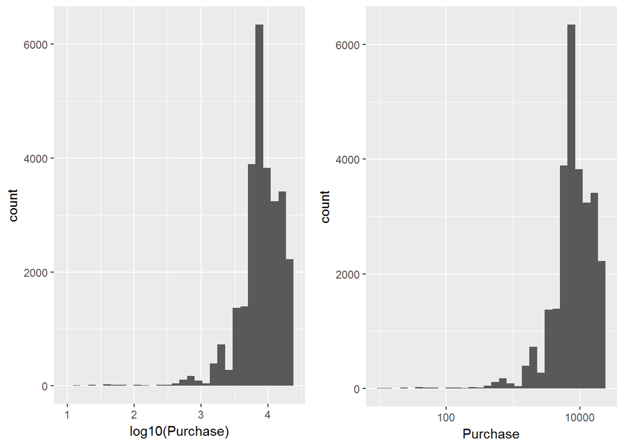

```r
logScale<-qplot(x=log10(Purchase),data=Pdata) # x ais is not scaled by log10
countScale<-ggplot(aes(x=Purchase),data=Pdata)+geom_histogram()+scale_x_log10() # X-axis is scaled by log 10
grid.arrange(logScale,countScale,ncol=2)
```

Look at the gender inbalance in the data set

```r
table(Pdata$Gender)
```

```
##
##     F     M
##  6854 20869
```

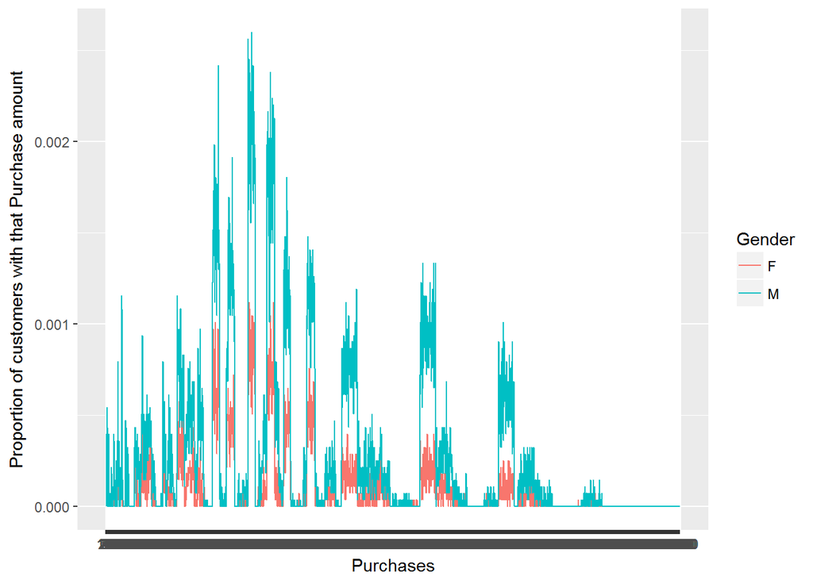

```r
ggplot(aes(x = Purchase, y = ..count../sum(..count..)), data = subset(Pdata, !is.na(Gender))) +
  geom_freqpoly(aes(color = Gender), binwidth=10) +
  scale_x_continuous(limits = c(0, 27723), breaks = seq(0, 27723, 50)) +
  xlab('Purchases') +
  ylab('Proportion of customers with that Purchase amount')
```

Lets zoom more on the right side , I think some places feamale shoppers overtake males in the case of higher purchases

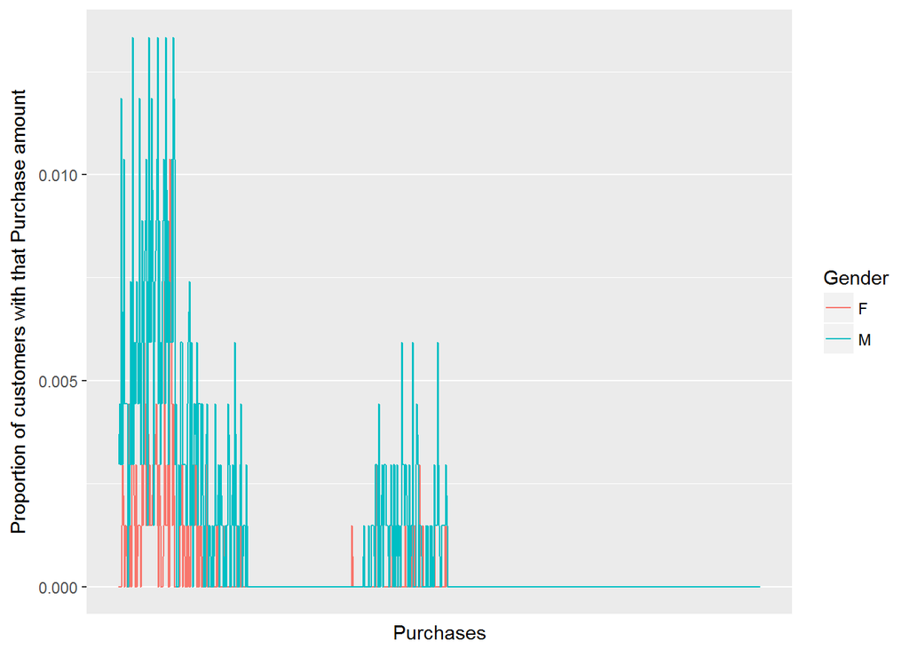

```r
ggplot(aes(x = Purchase, y = ..count../sum(..count..)), data = subset(Pdata, !is.na(Gender))) +
  geom_freqpoly(aes(color = Gender), binwidth=10) +
  scale_x_continuous(limits = c(20000, 27723), breaks = seq(0, 1000, 50)) +
  xlab('Purchases') +
  ylab('Proportion of customers with that Purchase amount')
```

This is where the feamle proportions overtake teh Male proportions

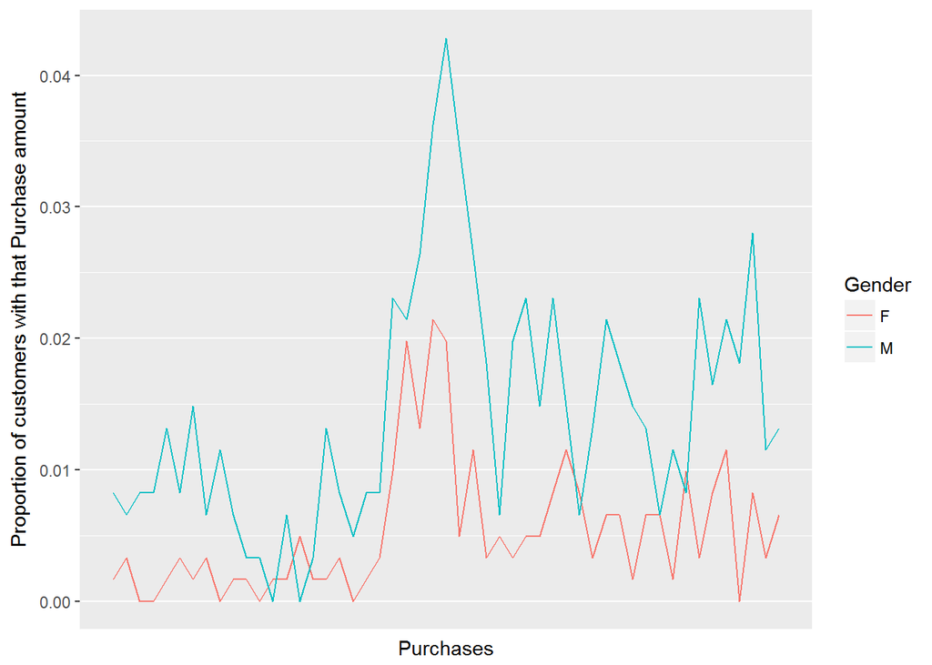

```r
ggplot(aes(x = Purchase, y = ..count../sum(..count..)), data = subset(Pdata, !is.na(Gender))) +
  geom_freqpoly(aes(color = Gender), binwidth=10) +
  scale_x_continuous(limits = c(1500, 2000), breaks = seq(0, 1000, 50)) +
  xlab('Purchases') +
  ylab('Proportion of customers with that Purchase amount')
```

How prices are distributed The below graph shows that the prices are spread in a multy model distribution

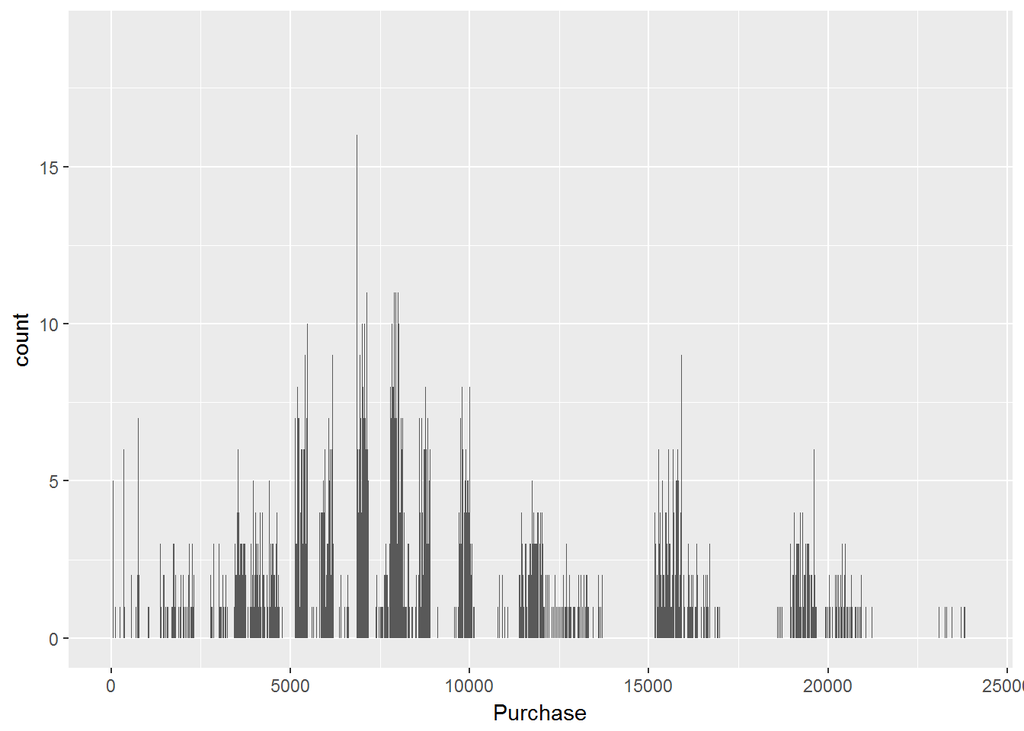

```r
ggplot(train[spl,],aes(x=Purchase))+geom_histogram(binwidth = 1)
```

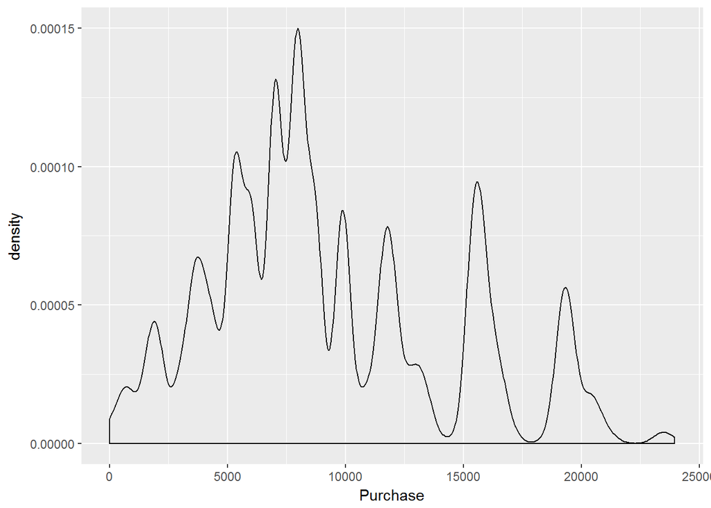

```r
ggplot(train,aes(x=Purchase))+geom_density()
```

[figure not shown]

```r
ggplot(train,aes(x=Purchase))+geom_dotplot(binwidth = 100)
```

```r
by(Pdata$Purchase,Pdata$Gender,summary)
```

```
## Pdata$Gender: F
##    Min. 1st Qu.  Median    Mean 3rd Qu.    Max.
##      12    5418    7894    8691   11410   23950
## --------------------------------------------------------
## Pdata$Gender: M
##    Min. 1st Qu.  Median    Mean 3rd Qu.    Max.
##      12    5892    8099    9476   12540   23950
```

There is a gender imbalance

Even though there are more outliers in the feamle box plot, their proportion is less compared to male in the case of higher purchases.

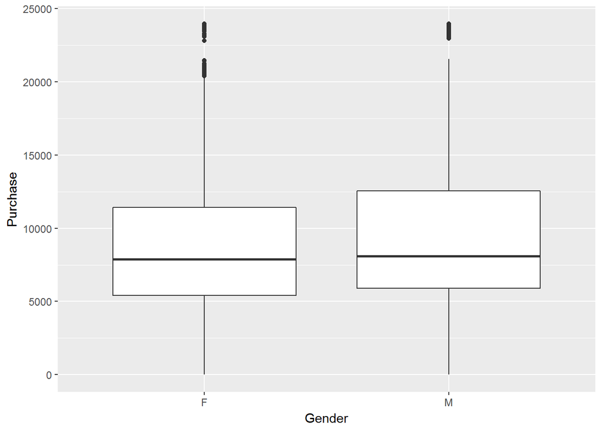

```r
qplot(x=Gender, y=Purchase,data=subset(Pdata, !is.na(Gender)),geom='boxplot')
```

Outlier : is 1.5 times IQR distance from the median. Set the limits to remove the outliers. So when we see these plots it is clear that the female customers shoppe less than the male

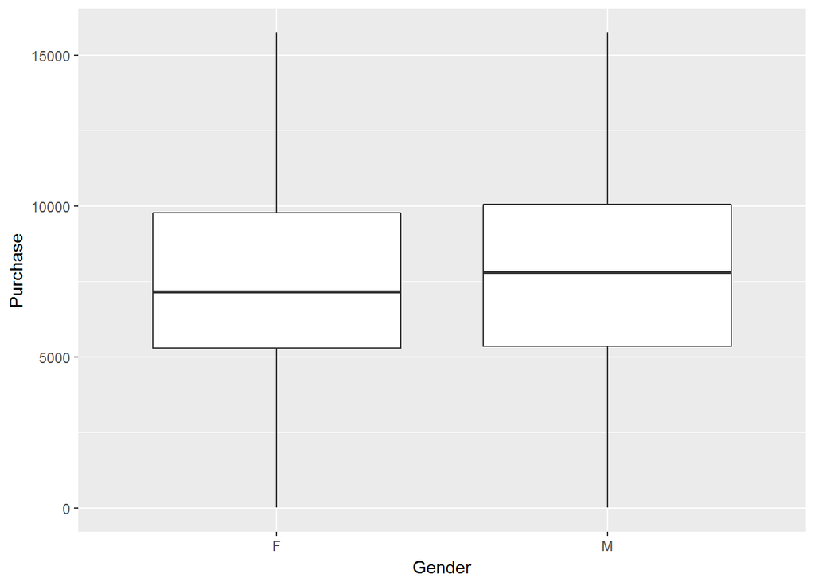

```r
qplot(x=Gender, y=Purchase,data=subset(Pdata, !is.na(Gender)),geom='boxplot',ylim=c(0,15750))
```

Set the limits to remove the outliers To match the graph details with the above statistics use the coord_cartesian function

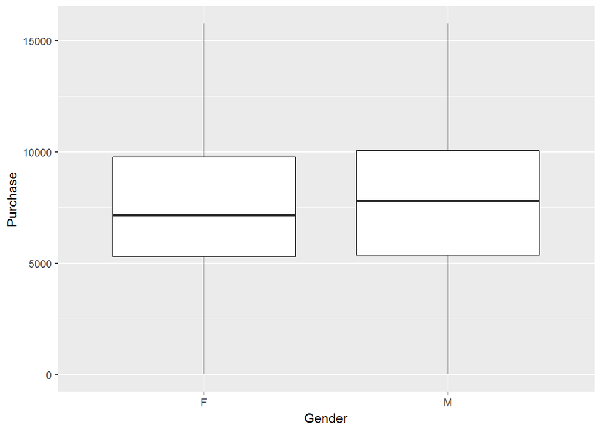

```r
qplot(x=Gender, y=Purchase,data=subset(Pdata, !is.na(Gender)),geom='boxplot')+
scale_y_continuous(limits=c(0,15750))
```

This is to summarize the Purchases by Gender numerically. Coord cartesian will not exclude any observation while summarizing , they will be just left while displaying on the graph, when a ylim is given

```r
by(Pdata$Purchase,Pdata$Gender,summary)
```

```
## Pdata$Gender: F
##    Min. 1st Qu.  Median    Mean 3rd Qu.    Max.
##      12    5418    7894    8691   11410   23950
## --------------------------------------------------------
## Pdata$Gender: M
##    Min. 1st Qu.  Median    Mean 3rd Qu.    Max.
##      12    5892    8099    9476   12540   23950
```

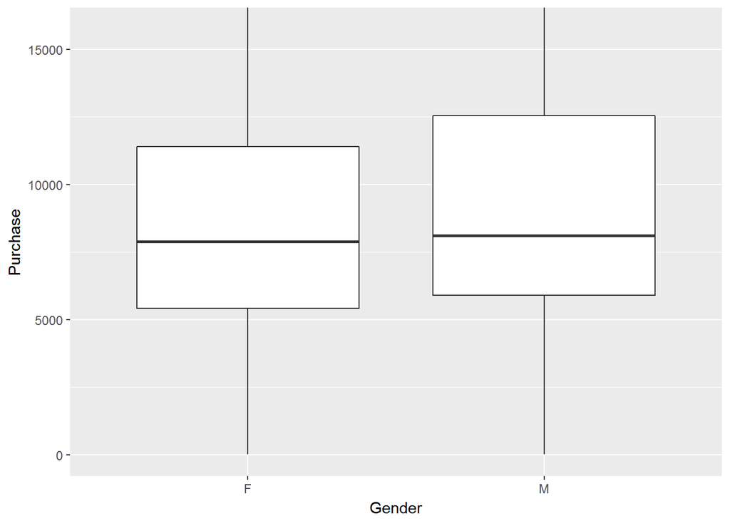

```r
qplot(x=Gender, y=Purchase,data=subset(Pdata, !is.na(Gender)),geom='boxplot')+coord_cartesian(ylim=c(0,15750))
```

product_count is the number of times the product is appearing. This means products appearing from 50 to 500 are sold more frequently compared to 1000 to the end. This means very less proportion ifrequently sold

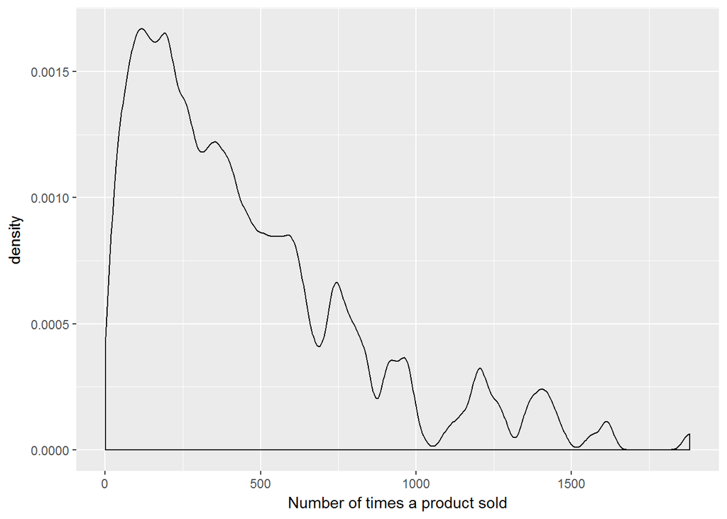

```r
ggplot(X_train,aes(x=Product_Count))+xlab('Number of times a product sold')+geom_density()
```

Below plot shows the distribution of purchase frequencies and distribution of Occupation frequencies and age frequencies as weoll

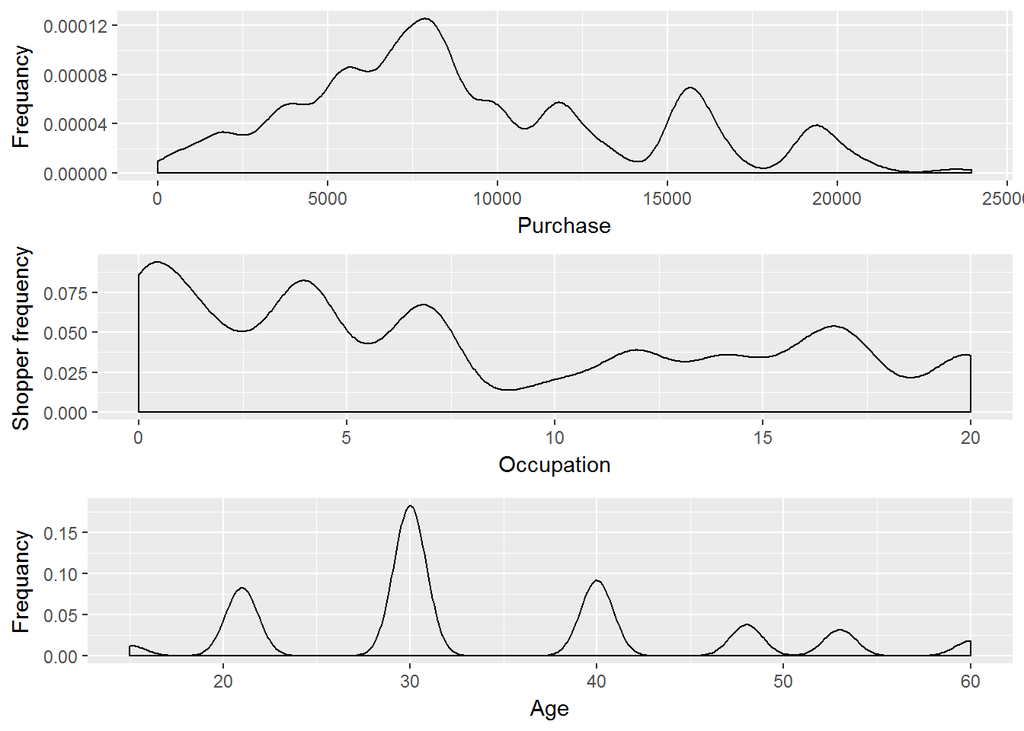

```r
library(gridExtra)
pl1<-ggplot(X_train[spl,],aes(x=Purchase))+geom_density()+ylab('Frequancy')
pl2<-ggplot(X_train[spl,],aes(x=Occupation))+geom_density()+ylab('Shopper frequency')
pl3<-ggplot(X_train[spl,],aes(x=Age))+geom_density()+ylab('Frequancy')
grid.arrange(pl1,pl2,pl3,ncol=1)
```

If we take product frequency(Product_count) , the city C has higher frequency

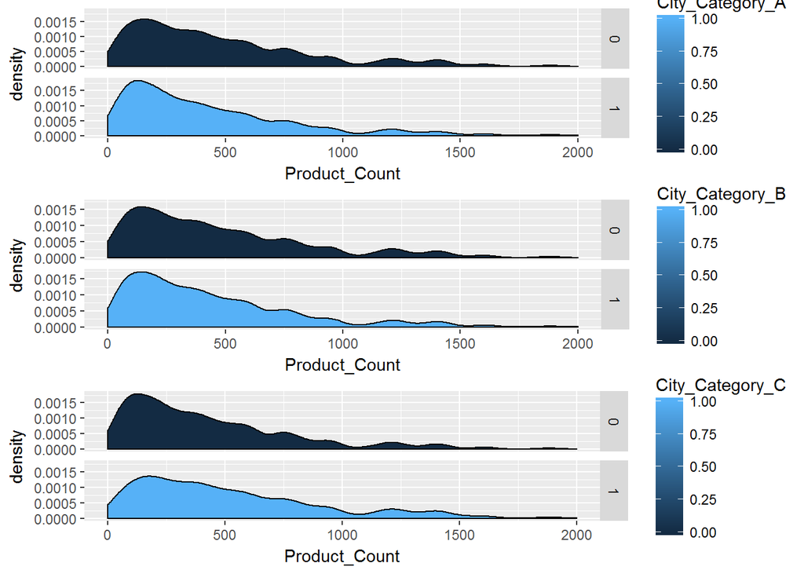

```r
pl1<-ggplot(X_train[spl,],aes(x=Product_Count,fill=City_Category_A))+geom_density()+facet_grid(City_Category_A ~.)+
     scale_x_continuous(limits = c(0,2000))
pl2<-ggplot(X_train[spl,],aes(x=Product_Count,fill=City_Category_B))+geom_density()+facet_grid(City_Category_B ~.)+
     scale_x_continuous(limits = c(0,2000))
pl3<-ggplot(X_train[spl,],aes(x=Product_Count,fill=City_Category_C))+geom_density()+facet_grid(City_Category_C ~.)+
     scale_x_continuous(limits = c(0,2000))
grid.arrange(pl1,pl2,pl3,ncol=1)
```

When we zoomed more on the right, City B has more number of products that are sold less frequently

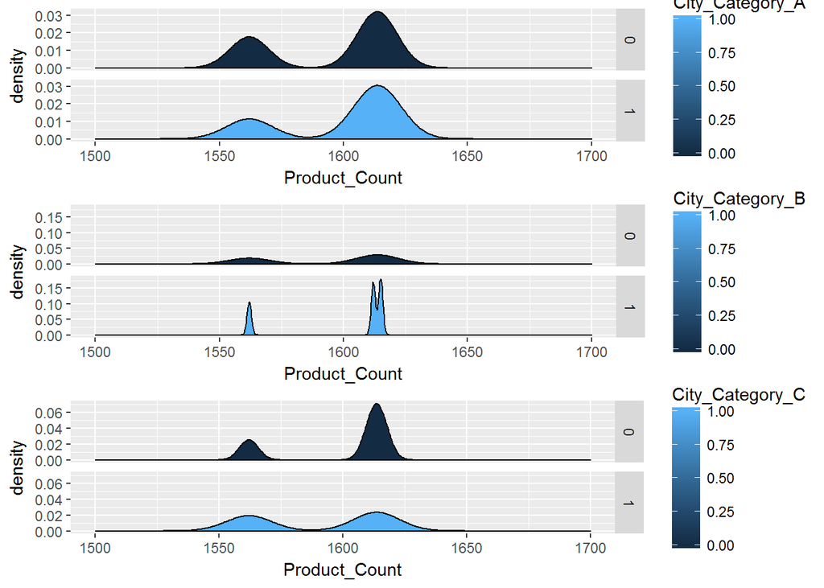

```r
pl1<-ggplot(X_train[spl,],aes(x=Product_Count,fill=City_Category_A))+geom_density()+facet_grid(City_Category_A ~.)+
  scale_x_continuous(limits = c(1500,1700))
pl2<-ggplot(X_train[spl,],aes(x=Product_Count,fill=City_Category_B))+geom_density()+facet_grid(City_Category_B ~.)+
  scale_x_continuous(limits = c(1500,1700))
pl3<-ggplot(X_train[spl,],aes(x=Product_Count,fill=City_Category_C))+geom_density()+facet_grid(City_Category_C ~.)+
scale_x_continuous(limits = c(1500,1700))
grid.arrange(pl1,pl2,pl3,ncol=1)
```

How Marrital status is effecting the purchase?

Check for imbalance

```r
table(Pdata$Marital_Status)
```

```
##
##     M    UM
## 11345 16378
```

Imbalance observed

```r
by(Pdata$Purchase,Pdata$Marital_Status,summary)
```

```
## Pdata$Marital_Status: M
##    Min. 1st Qu.  Median    Mean 3rd Qu.    Max.
##      12    5882    8040    9306   12060   23950
## --------------------------------------------------------
## Pdata$Marital_Status: UM
##    Min. 1st Qu.  Median    Mean 3rd Qu.    Max.
##      12    5481    8042    9265   12070   23950
```

How about the purchases in the case of married an unmarried? Unmarried are the frquent shoppers

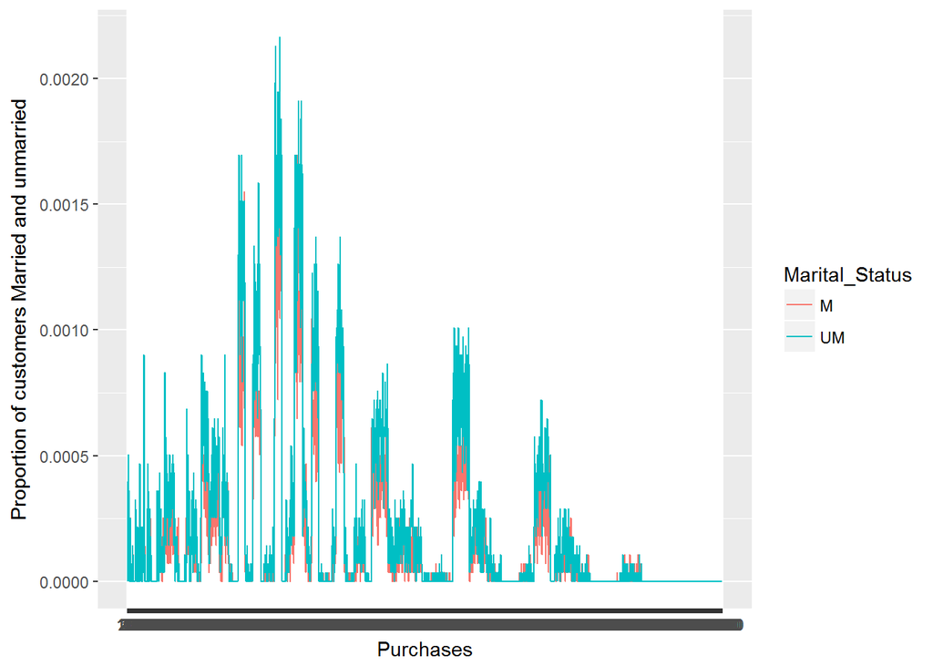

```r
ggplot(aes(x = Purchase, y = ..count../sum(..count..)), data = subset(Pdata, !is.na(Marital_Status))) +
  geom_freqpoly(aes(color = Marital_Status), binwidth=10) +
  scale_x_continuous(limits = c(0, 27723), breaks = seq(0, 27723, 50)) +
  xlab('Purchases') +
  ylab('Proportion of customers Married and unmarried')
```